# People Based ML - Targeting A Housing Subsidy

## Cost-Benefit Calculation

The cost/benefit for a True Negative (No marketing resources used and no money gained) is 0 * Count;

The cost/benefit for a False Positive (Marketing resources used and no money gained) is (-2850) * Count;

The cost/benefit for a False Negative (No marketing resources used and no money gained) is 0 * Count;

```r
cost_benefit_table <-
   testProbs %>%
      count(predOutcome, Outcome) %>%
      summarize(True_Negative = sum(n[predOutcome==0 & Outcome==0]),
                True_Positive = sum(n[predOutcome==1 & Outcome==1]),
                False_Negative = sum(n[predOutcome==0 & Outcome==1]),
                False_Positive = sum(n[predOutcome==1 & Outcome==0])) %>%
       gather(Variable, Count) %>%
       mutate(Revenue =
               ifelse(Variable == "True_Negative", Count * 0,
               ifelse(Variable == "True_Positive",(-(2850 + 5000 / 4) * Count + 66000 / 4 * Count),
               ifelse(Variable == "False_Negative", Count * 0,
               ifelse(Variable == "False_Positive", (-2850) * Count, 0))))) %>%
    bind_cols(data.frame(Description = c(
              "We correctly predicted not joining tax credit",
              "We correctly predicted a tax credit",
              "We predicted no participation and customer participated",
              "We predicted a participation and customer did not participate")))

kable(cost_benefit_table, caption = "Cost/Benefit Table", format = "html") %>%
  kable_styling(position = "center") %>%
  column_spec(1, bold = TRUE, color = "#67b8b4") %>%
  row_spec(0, bold = TRUE, color = "#364d36", background = "#fee8ff")
```

Cost/Benefit Table

| Variable | Count | Revenue | Description |
| --- | --- | --- | --- |
| True_Negative | 1260 | 0 | We correctly predicted not joining tax credit |
| True_Positive | 33 | 409200 | We correctly predicted a tax credit |
| False_Negative | 124 | 0 | We predicted no participation and customer participated |
| False_Positive | 23 | -65550 | We predicted a participation and customer did not participate |

## Optimize Thresholds

The last step to tuning our model is to run it for each threshold value. We can then look at the confusion matrices for each threshold and choose the one that returns the most revenue.

```r
iterateThresholds <- function(data) {
  x = .01
  all_prediction <- data.frame()
  while (x <= 1) {

  this_prediction <-
      testProbs %>%
      mutate(predOutcome = ifelse(Probs > x, 1, 0)) %>%
      count(predOutcome, Outcome) %>%
      summarize(True_Negative = sum(n[predOutcome==0 & Outcome==0]),
                True_Positive = sum(n[predOutcome==1 & Outcome==1]),
                False_Negative = sum(n[predOutcome==0 & Outcome==1]),
                False_Positive = sum(n[predOutcome==1 & Outcome==0])) %>%
     gather(Variable, Count) %>%
     mutate(Revenue =
               ifelse(Variable == "True_Negative", Count * 0,
               ifelse(Variable == "True_Positive",(-(2850 + 5000 / 4) * Count + 66000 / 4 * Count),
               ifelse(Variable == "False_Negative", Count * 0,
               ifelse(Variable == "False_Positive", (-2850) * Count, 0)))),
            Threshold = x)

  all_prediction <- rbind(all_prediction, this_prediction)
  x <- x + .01
  }
return(all_prediction)
}
```

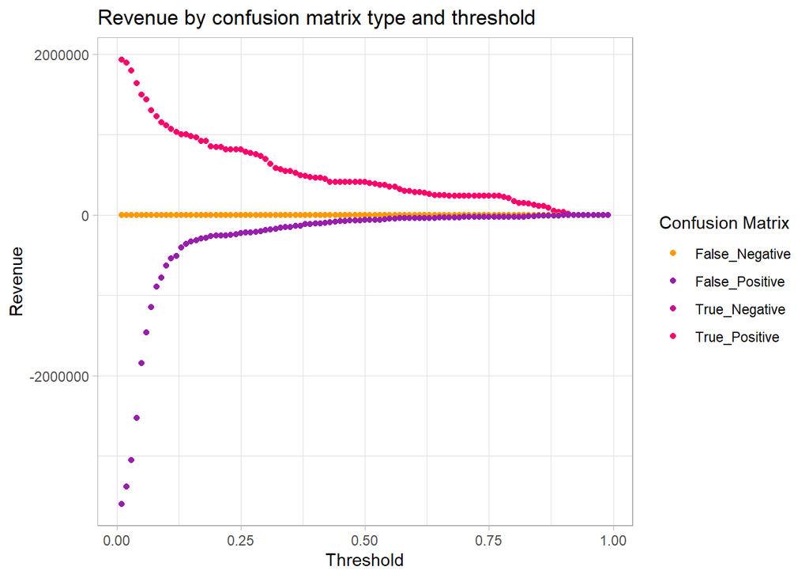

```r
whichThreshold <- iterateThresholds(testProbs)
whichThreshold %>%
  ggplot(.,aes(Threshold, Revenue, colour = Variable)) +
  geom_point() +
  scale_colour_manual(values = palette5[c(5, 1:3)]) +
  labs(title = "Revenue by confusion matrix type and threshold",
       y = "Revenue") +
  theme_light() +
  guides(colour=guide_legend(title = "Confusion Matrix"))
```

```r
whichThreshold_revenue <-
  whichThreshold %>%
    mutate(actualcredit = ifelse(Variable == "Count_TP", (Count * .25),
                         ifelse(Variable == "Count_FN", Count, 0))) %>%
    group_by(Threshold) %>%
    summarize(Revenue = sum(Revenue),
              actualcredit_Rate = sum(actualcredit) / sum(Count),
              actualcredit_Revenue_Loss =  sum(actualcredit * 30),
              Revenue_Next_Period = Revenue - actualcredit_Revenue_Loss)

whichThreshold_revenue[10:30,]
```

```
## # A tibble: 21 × 5
##    Threshold Revenue actualcredit_Rate actualcredit_Revenue_Loss
##        <dbl>   <dbl>             <dbl>                     <dbl>
##  1      0.1   483300                 0                         0
##  2      0.11  522050                 0                         0
##  3      0.12  516200                 0                         0
##  4      0.13  594000                 0                         0
##  5      0.14  642450                 0                         0
##  6      0.15  646150                 0                         0
##  7      0.16  653700                 0                         0
##  8      0.17  621200                 0                         0
##  9      0.18  632600                 0                         0
## 10      0.19  590550                 0                         0
## # ℹ 11 more rows
## # ℹ 1 more variable: Revenue_Next_Period <dbl>
```